# Summary

```r
library(tidyverse)
```

# 시계열 분석 Time Series Analysis

시간의 흐름에 따라 기록된 자료(data)의 인과관계를 분석하는 방법

# 정상성 Stationary

- 시계열 모델을 분석하기 위한 기본 가정. 평범하면서 한결같이 흔한 행동상태
- 어느 구간이든, 평균이 일정(0)
- 어느 구간이든, 분산이 일정(상수)

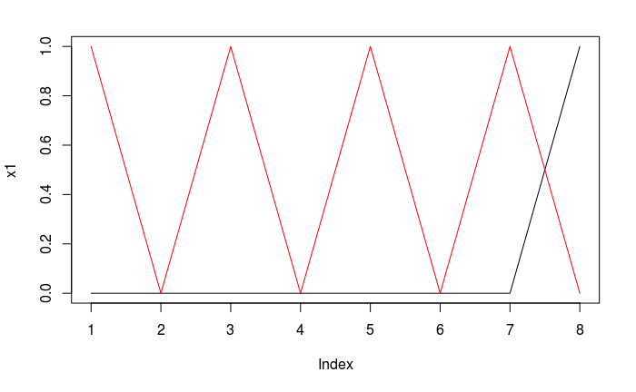

```r
#Dickey-Fuller 단위근 검정
library(tseries)
x1 <- c(0,0,0,0,0,0,0,1)
x2 <- c(1,0,1,0,1,0,1,0)
plot(x1, type = "l")
lines(x2, col=2)
```

```r
adf.test(x1) # non - stationary
```

```
p-value greater than printed p-value
```

```
    Augmented Dickey-Fuller Test

data:  x1
Dickey-Fuller = 1.7321, Lag order = 1, p-value = 0.99
alternative hypothesis: stationary
```

```r
adf.test(x2) # stationary
```

```
essentially perfect fit: summary may be unreliablep-value smaller than printed p-value
```

```
    Augmented Dickey-Fuller Test

data:  x2
Dickey-Fuller = -4.6521e+15, Lag order = 1, p-value = 0.01
alternative hypothesis: stationary
```

# 이동평균 Moving Average

과거의 평균적 수치에서 현상을 파악(주로 추세)하여 현재의 예측에 접목할 수 돕는 방법

```r
#X : vector, window_size = 3
movingAverage <- function( X , windowSize = 3){
  ma <- c()
  nLength <- length( X ) # 11

  for(i in 1:( nLength - windowSize + 1 ) ){
    ma <- c(ma, mean( X[  i:(i + windowSize - 1)  ] ) )
  }
  return (ma)
}
```

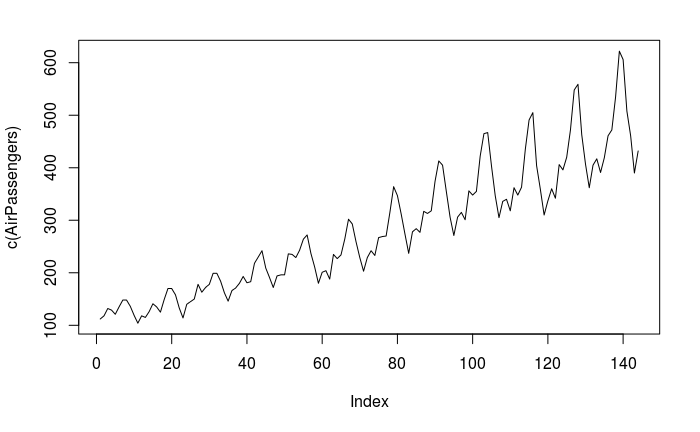

```r
library(pracma)
# 실제 데이터
plot(c(AirPassengers), type = "l")
```

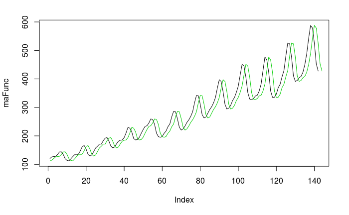

```r
# 구현한 함수와 패키지 비교
maFunc <- movingAverage(AirPassengers, 3)
maPack <- movavg(AirPassengers, 3, type="s")
plot(maFunc, type="l")
lines(maPack, col=3)
```

# 자귀회귀 Auto Regression

- Auto의 사전적 의미는 ‘자기 스스로’
- 어제의 자기 자신 데이터로 오늘의 데이터를 설명하는 방법

### 데이터 생성

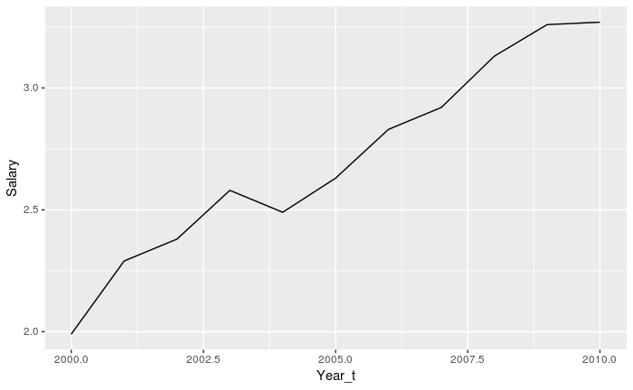

```r
tbl <- tribble(
  ~Year_t,  ~Salary,
  2000, 1.99,
  2001, 2.29,
  2002, 2.38,
  2003, 2.58,
  2004, 2.49,
  2005, 2.63,
  2006, 2.83,
  2007, 2.92,
  2008, 3.13,
  2009, 3.26,
  2010, 3.27
)
ggplot(tbl, mapping = aes(Year_t, Salary)) + geom_line()
```

### Step by Step

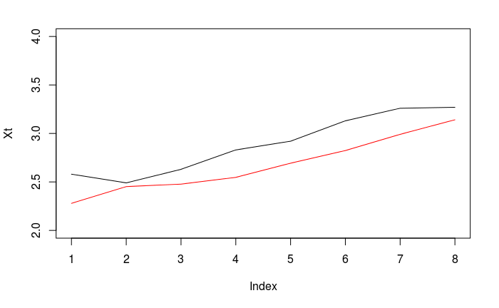

```r
mu <- mean(tbl$Salary)
Xt   <- tbl$Salary[4:11]
Xt_1 <- tbl$Salary[3:10]
Xt_2 <- tbl$Salary[2:9]
Xt_3 <- tbl$Salary[1:8]
tbl2 <- tibble(Xt, Xt_1, Xt_2, Xt_3)
model <- lm(tbl2, formula = Xt~Xt_1+Xt_2+Xt_3)
beta <- model$coefficients
mat <-tbl2 %>%
      select( Xt_1, Xt_2, Xt_3 ) %>%
      mutate(b0 = 0) %>%
      select(b0, Xt_1, Xt_2, Xt_3) %>%
      as.matrix(ncol = 3, byrow = TRUE)
Xt_hat <- mat %*% matrix(as.vector(beta), ncol = 1) %>% as.vector()
plot(Xt, type = "l", ylim = c(2,4))
lines(Xt_hat, col=2)
```

### 패키지 결과값과 비교

```r
library(stats)
# stats::ar.mle
model.ar.mle <- ar.mle(tbl$Salary, aic = FALSE, order.max = 3)
xt_hat_package <- tbl2 %>% select(Xt_1, Xt_2, Xt_3 ) %>% as.matrix() %*% model.ar.mle$ar
# 시각화
plot(tbl2$Xt, type = "l", ylim = c(2,4))
lines(Xt_hat, col=2)
```

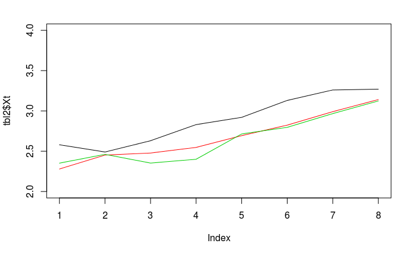

```r
lines(xt_hat_package, col=3)
```

# 자기상관, 편자기상관 ACF, PACF

### 자기상관함수(auto correlation)

- 과거의 데이터와 현재의 데이터가 서로 상관 관계를 가지고 있는가?

```r
tData <- c(409,289,509,364,404,445,310,372,440,414,380,598,418,359,432,252,446,473,337,478)
# 개념에 따라 직접 계산
cor(data.frame(tData[3:20],tData[2:19],tData[1:18] ))
```

```
            tData.3.20. tData.2.19. tData.1.18.
tData.3.20.   1.0000000  -0.3567812  -0.0902651
tData.2.19.  -0.3567812   1.0000000  -0.3117630
tData.1.18.  -0.0902651  -0.3117630   1.0000000
```

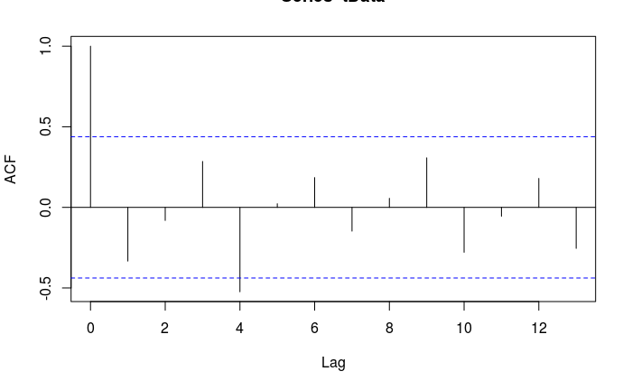

```r
# 1.0000000  -0.3567812  -0.0902651 ....
# 패키지 결과
tData.acf <- acf(tData)
```

```r
tData.acf$acf
```

```
, , 1

             [,1]
 [1,]  1.00000000
 [2,] -0.33315916
 [3,] -0.08111436
 [4,]  0.28490420
 [5,] -0.52349511
 [6,]  0.02269724
 [7,]  0.18481079
 [8,] -0.14710195
 [9,]  0.05628129
[10,]  0.30735875
[11,] -0.27848706
[12,] -0.05473779
[13,]  0.17975431
[14,] -0.25422747
```

```r
#1.00000000  -0.33315916 -0.08111436 .....
```

# PACF(Partial AutoCorrelation function)

### Partial의 의미

- 교회수와 범죄수와의 관계
- 또다른 설명변수
- Partial의 의미

```r
X = c(2,4,15,20) # of church
Y = c(1,2,3,4)   # of crime
Z = c(100,120,150,200)   # of population
mm1 = lm(X~Z)
res1 = mm1$residuals
mm2 = lm(Y~Z)
res2 = mm2$residuals
cor(X,Y) # 교회와 범죄수 간의 관계
```

```
[1] 0.9695016
```

```r
cor(res1,res2) # 인구의 영향을 뺀 교회와 범죄의 관계
```

```
[1] 0.4840019
```

### PACF 함수

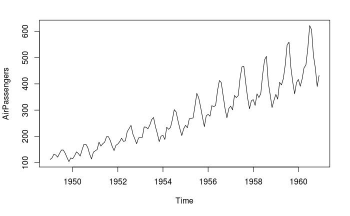

```r
plot(AirPassengers)
```

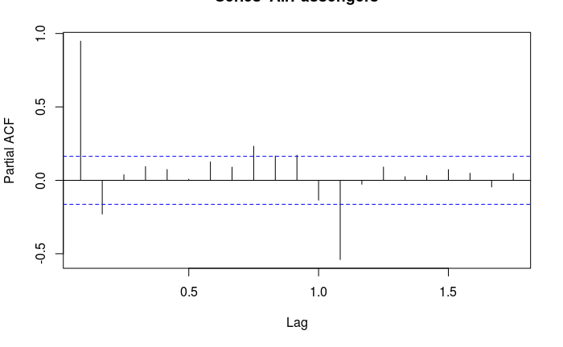

```r
model.pacf <- pacf(AirPassengers)
```

```r
model.pacf$acf
```

```
, , 1

              [,1]
 [1,]  0.948047341
 [2,] -0.229421874
 [3,]  0.038147781
 [4,]  0.093785438
 [5,]  0.073606698
 [6,]  0.007727603
 [7,]  0.125597130
 [8,]  0.089951343
 [9,]  0.232488542
[10,]  0.166051260
[11,]  0.171274420
[12,] -0.135431102
[13,] -0.539691242
[14,] -0.026610140
[15,]  0.090764982
[16,]  0.024955559
[17,]  0.032515570
[18,]  0.073432641
[19,]  0.048442115
[20,] -0.045541680
[21,]  0.045752935
```

# 차분 Difference

- 현재값에서 이전값을 뺀 차이( delta. 추세의 미분 )
- 추세를 미분하여 없앤다.

### 차분, 그리고 미분

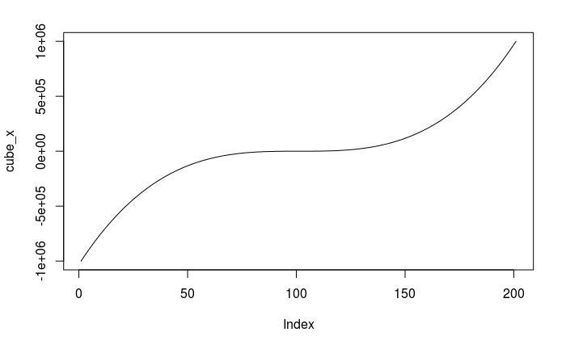

```r
cube_x <- (-100:100)^3
plot( cube_x, type = "l")
```

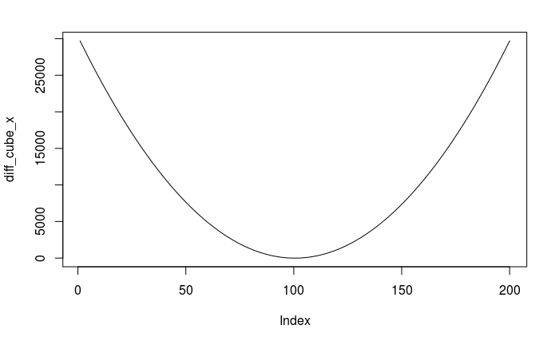

```r
diff_cube_x <- diff(cube_x)
plot( diff_cube_x, type = "l")
```

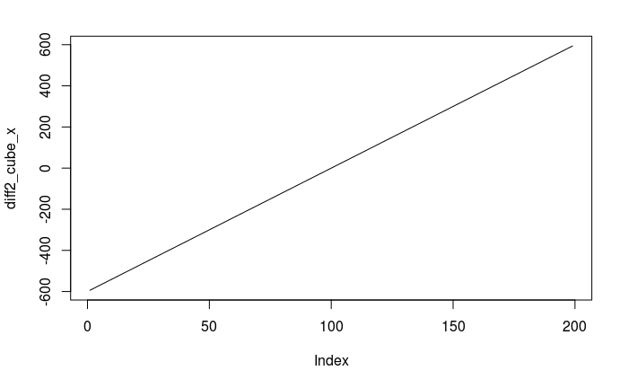

```r
diff2_cube_x <- diff(diff_cube_x)
plot( diff2_cube_x, type = "l")
```

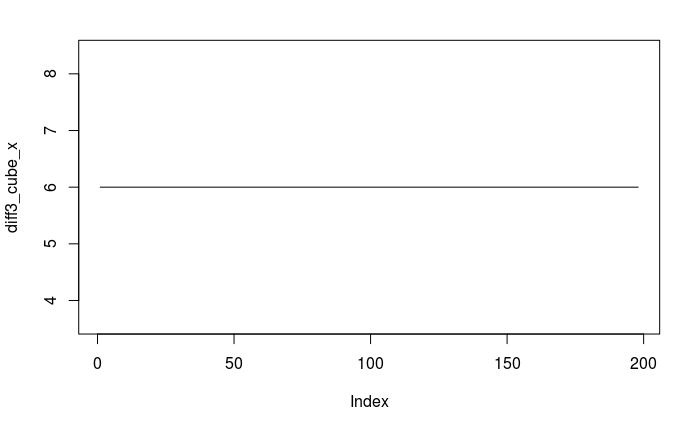

```r
diff3_cube_x <- diff(diff2_cube_x)
plot( diff3_cube_x, type = "l")
```

### Step by Step

diff(x) = Xt - Xt-1

```r
AP <- c(AirPassengers)
AP.diff1 <- AP[2:144] - AP[1:143] # diff 함수
AP.diff1
```

```
  [1]    6   14   -3   -8   14   13    0  -12  -17  -15   14   -3   11   15   -6  -10   24   21    0  -12  -25  -19   26    5    5   28  -15    9
 [29]    6   21    0  -15  -22  -16   20    5    9   13  -12    2   35   12   12  -33  -18  -19   22    2    0   40   -1   -6   14   21    8  -35
 [57]  -26  -31   21    3  -16   47   -8    7   30   38   -9  -34  -30  -26   26   13   -9   34    2    1   45   49  -17  -35  -38  -37   41    6
 [85]   -7   40   -4    5   56   39   -8  -50  -49  -35   35    9  -14   55   -8    7   67   43    2  -63  -57  -42   31    4  -22   44  -14   15
[113]   72   56   14 -101  -45  -49   27   23  -18   64  -10   24   52   76   11  -96  -56  -45   43   12  -26   28   42   11   63   87  -16  -98
[141]  -47  -71   42
```

R 함수에서 확인

```r
diff(AirPassengers) # diff 함수
```

```
      Jan  Feb  Mar  Apr  May  Jun  Jul  Aug  Sep  Oct  Nov  Dec
1949         6   14   -3   -8   14   13    0  -12  -17  -15   14
1950   -3   11   15   -6  -10   24   21    0  -12  -25  -19   26
1951    5    5   28  -15    9    6   21    0  -15  -22  -16   20
1952    5    9   13  -12    2   35   12   12  -33  -18  -19   22
1953    2    0   40   -1   -6   14   21    8  -35  -26  -31   21
1954    3  -16   47   -8    7   30   38   -9  -34  -30  -26   26
1955   13   -9   34    2    1   45   49  -17  -35  -38  -37   41
1956    6   -7   40   -4    5   56   39   -8  -50  -49  -35   35
1957    9  -14   55   -8    7   67   43    2  -63  -57  -42   31
1958    4  -22   44  -14   15   72   56   14 -101  -45  -49   27
1959   23  -18   64  -10   24   52   76   11  -96  -56  -45   43
1960   12  -26   28   42   11   63   87  -16  -98  -47  -71   42
```

2차 차분

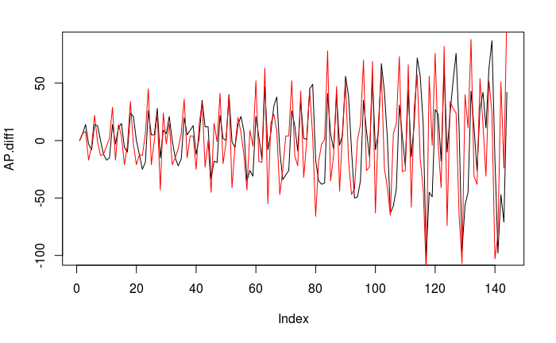

```r
AP.diff1 <- c(0, AP[2:144] - AP[1:143]) # diff 함수
AP.diff2 <- c(0, AP.diff1[2:144] - AP.diff1[1:143]) # diff 함수
plot(AP.diff1, type = "l")
lines(AP.diff2, col = 2)
```

2차 차분 - 패키지에서 확인

```r
AP.diff2
```

```
  [1]    0    6    8  -17   -5   22   -1  -13  -12   -5    2   29  -17   14    4  -21   -4   34   -3  -21  -12  -13    6   45  -21    0   23  -43
 [29]   24   -3   15  -21  -15   -7    6   36  -15    4    4  -25   14   33  -23    0  -45   15   -1   41  -20   -2   40  -41   -5   20    7  -13
 [57]  -43    9   -5   52  -18  -19   63  -55   15   23    8  -47  -25    4    4   52  -13  -22   43  -32   -1   44    4  -66  -18   -3    1   78
 [85]  -35  -13   47  -44    9   51  -17  -47  -42    1   14   70  -26  -23   69  -63   15   60  -24  -41  -65    6   15   73  -27  -26   66  -58
[113]   29   57  -16  -42 -115   56   -4   76   -4  -41   82  -74   34   28   24  -65 -107   40   11   88  -31  -38   54   14  -31   52   24 -103
[141]  -82   51  -24  113
```

```r
diff(AirPassengers, differences = 2) %>% as.vector() # diff 함수
```

```
  [1]    8  -17   -5   22   -1  -13  -12   -5    2   29  -17   14    4  -21   -4   34   -3  -21  -12  -13    6   45  -21    0   23  -43   24   -3
 [29]   15  -21  -15   -7    6   36  -15    4    4  -25   14   33  -23    0  -45   15   -1   41  -20   -2   40  -41   -5   20    7  -13  -43    9
 [57]   -5   52  -18  -19   63  -55   15   23    8  -47  -25    4    4   52  -13  -22   43  -32   -1   44    4  -66  -18   -3    1   78  -35  -13
 [85]   47  -44    9   51  -17  -47  -42    1   14   70  -26  -23   69  -63   15   60  -24  -41  -65    6   15   73  -27  -26   66  -58   29   57
[113]  -16  -42 -115   56   -4   76   -4  -41   82  -74   34   28   24  -65 -107   40   11   88  -31  -38   54   14  -31   52   24 -103  -82   51
[141]  -24  113
```

# 자기회귀이동평균 ARMA

ARIMA 모델은 시계열 분석 기법의 한 종류로, 과거의 관측값과 오차를 사용해서 현재의 시계열 값을 설명하는 ARMA 모델을 일반화

(김용태 교수님 강의자료 참고)

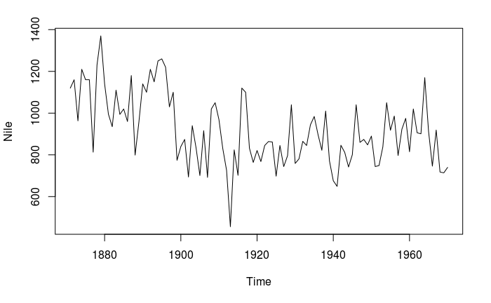

```r
#detach("package:aTSA", unload = TRUE)
library(tseries)
library(forecast)
library(datasets)
plot(Nile)
```

p > 0.05 이므로 정상성을 만족하지 않음

```r
Nile %>% adf.test()
```

```
    Augmented Dickey-Fuller Test

data:  .
Dickey-Fuller = -3.3657, Lag order = 4, p-value = 0.0642
alternative hypothesis: stationary
```

p < 0.05 이므로 정상성을 만족

```r
Nile.diff <- Nile %>% diff(differences=1)
Nile.diff %>% adf.test()
```

```
p-value smaller than printed p-value
```

```
    Augmented Dickey-Fuller Test

data:  .
Dickey-Fuller = -6.5924, Lag order = 4, p-value = 0.01
alternative hypothesis: stationary
```

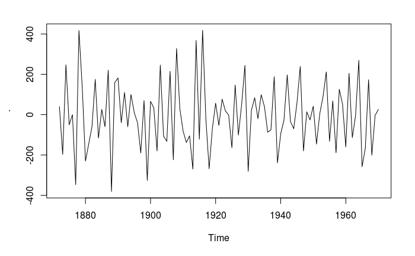

```r
Nile.diff %>% plot()
```

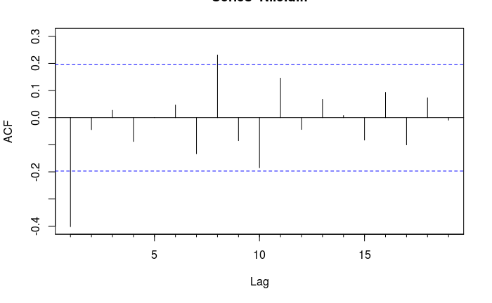

```r
Acf(Nile.diff)
```

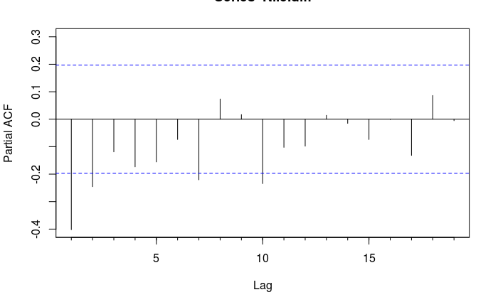

```r
Pacf(Nile.diff)
```

ARIMA(0,1,1) 적용

```r
fit.arima <- Nile %>% arima(order = c(0,1,1))
fit.arima
```

```
Call:
arima(x = ., order = c(0, 1, 1))

Coefficients:
          ma1
      -0.7329
s.e.   0.1143

sigma^2 estimated as 20600:  log likelihood = -632.55,  aic = 1269.09
```

예측하기

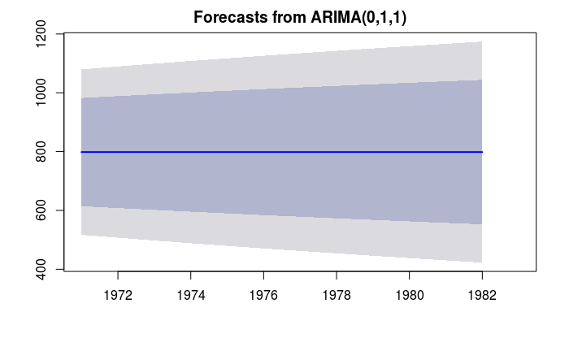

```r
forecast(fit.arima, h = 12) %>% plot()
```

# 지수평활법

시계열 데이터를 부드럽게 변환하기 위한 smoothing method. 수많은 모델들이 있으니, 아래 논문 5페이지를 참고하기 바람

> https://www.bauer.uh.edu/gardner/Exponential-Smoothing.pdf

한글자료

> http://ko.logpresso.com/documents/time-series

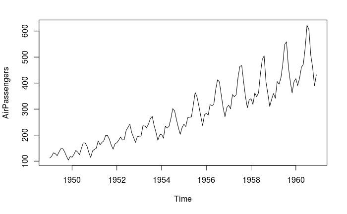

```r
plot(AirPassengers)
```

> St = a * Xt + ( 1-a ) * Xt_1

```
$estimate
          Jan      Feb      Mar      Apr      May      Jun      Jul      Aug      Sep      Oct      Nov      Dec
1949 112.0000 114.2222 117.2799 122.8372 126.8133 128.2713 132.3799 138.5971 143.7695 145.3433 142.6454 136.6701
1950 134.2952 131.3873 131.1472 134.1633 135.3940 134.1587 138.2843 146.4552 153.4897 156.8126 153.9675 147.0466
1951 146.5608 147.1393 148.6625 156.1012 159.1981 163.7462 168.8860 177.8345 185.4407 188.4952 185.9787 179.9203
1952 178.7794 178.7022 180.4678 184.7453 185.6881 186.7855 195.3233 205.2866 216.4334 218.5936 216.1385 209.4413
1953 208.1572 207.2728 206.3270 214.1977 220.7340 224.9378 231.4826 241.6059 251.9471 252.9041 247.5838 235.6988
1954 229.6573 224.8817 217.0816 220.6203 221.9861 224.7327 233.7601 250.0246 262.1447 264.9743 260.4775 250.4650
1955 247.2012 247.0802 244.8858 250.3977 255.6005 260.2672 274.1576 296.9691 312.8760 318.5830 314.6061 302.3840
1956 300.2909 299.4720 296.9418 303.3417 307.8657 312.6992 329.0619 351.7266 369.3844 373.2067 365.0437 349.5252
1957 343.1903 339.3265 332.6252 338.7583 342.2601 346.7309 365.2988 390.8607 413.3198 418.4901 409.7151 392.0813
1958 382.9888 375.6060 364.0819 363.6187 360.1179 360.3782 376.5640 403.1317 429.3395 429.5700 419.2625 398.9067
1959 386.7134 380.9940 371.9942 378.3132 381.7423 390.0944 408.9075 442.0984 473.3224 478.8835 470.6126 452.6999
1960 445.9614 442.3583 433.1901 431.1556 438.5589 447.3885 468.9042 506.7533 535.9306 539.0820 530.5525 506.5576

$alpha
[1] 0.2

$beta
[1] 0.1057

$accurate
          SST           SSE           MSE          RMSE          MAPE           MPE           MAE            ME     R.squared R.adj.squared
 2.058044e+06  3.437755e+05  2.420954e+03  4.920320e+01  1.230013e+01 -1.757674e+00  3.616718e+01  1.042081e-01  8.329601e-01  8.317837e-01
 RW.R.squared           AIC           SBC           APC
 3.478452e+18  1.124022e+03  1.129962e+03  2.454579e+03

attr(,"class")
[1] "Holt"
```

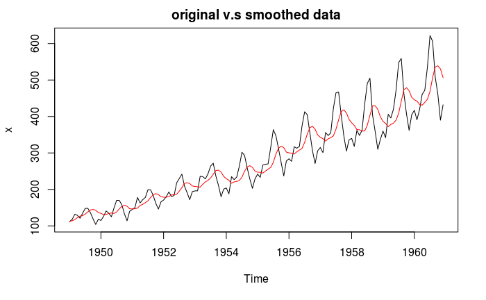

```r
#install.packages("aTSA")
library(aTSA)
AirPassengers %>% Holt()
```

### 이중 지수 평활법

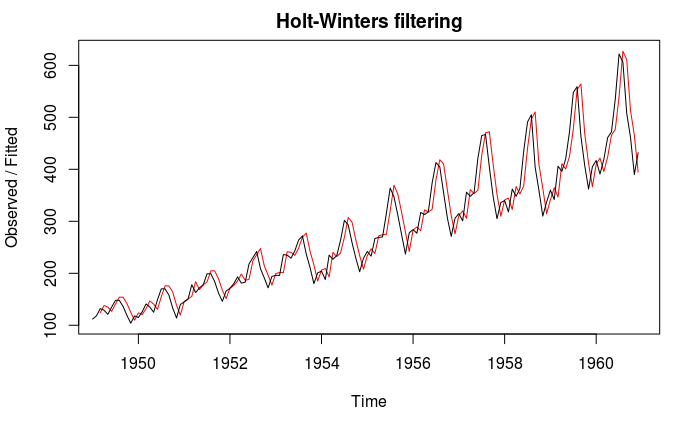

```r
double <- AirPassengers %>% HoltWinters(gamma = F)
plot(double)
```

### 가법 지수 평활법

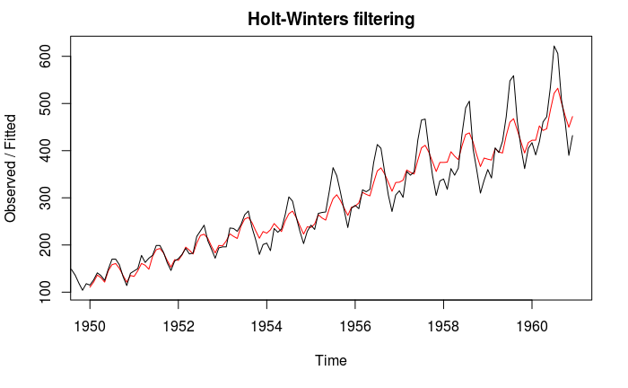

```r
additive <- AirPassengers %>% HoltWinters(seasonal = "additive", alpha =0.1 , beta =0.1 , gamma = 0.1)
plot(additive)
```

### 승법 지수 평활법

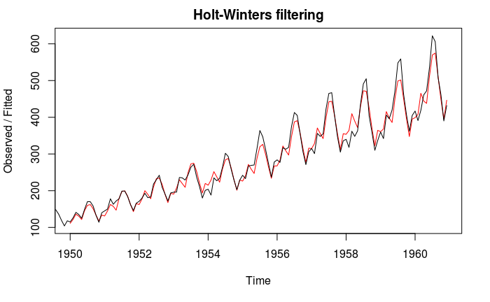

```r
multiplicative <- AirPassengers %>% HoltWinters(seasonal = "multiplicative", alpha =0.1 , beta =0.1 , gamma = 0.1)
plot(multiplicative)
```

# ggplot

- tidyverse 산하의 R 시각화 패키지
- 아래 사이트와 Cheetsheet 참조

> https://ggplot2.tidyverse.org/index.html

> https://www.rstudio.com/wp-content/uploads/2015/03/ggplot2-cheatsheet.pdf

# tidydata

> Happy families are all alike; every unhappy family is unhappy in its own way. - leo tolstoy

> Tidy datasets are all alike, but every messy dataset is messy in its own way. - Hadley Wickham

### Introduction

- tidy data 라고 불리는 일관된 구조로 데이터를 변환하는 방법
- 데이터를 분석 그 자체에 좀 더 집중 할 수 있도록 함
- tidyr은 tidyverse의 주요 패키지
- tidyr 패키지를 이용하여 tidy data를 구성하는 방법을 배울 것임

### Tidy Data

아래 데이터셋들은 각각 서로 다른 country, year, population, cases 를 인자로 가지고 있다. 모두 동일한 데이터를 담고 있지만, 형식이 달라 동일하게 사용하기 어렵다.

```r
table1
```

| country | year | cases | population |
| --- | --- | --- | --- |
| Afghanistan | 1999 | 745 | 19987071 |
| Afghanistan | 2000 | 2666 | 20595360 |
| Brazil | 1999 | 37737 | 172006362 |
| Brazil | 2000 | 80488 | 174504898 |
| China | 1999 | 212258 | 1272915272 |
| China | 2000 | 213766 | 1280428583 |

```r
table2
```

| country | year | type | count |
| --- | --- | --- | --- |
| Afghanistan | 1999 | cases | 745 |
| Afghanistan | 1999 | population | 19987071 |
| Afghanistan | 2000 | cases | 2666 |
| Afghanistan | 2000 | population | 20595360 |
| Brazil | 1999 | cases | 37737 |
| Brazil | 1999 | population | 172006362 |
| Brazil | 2000 | cases | 80488 |
| Brazil | 2000 | population | 174504898 |
| China | 1999 | cases | 212258 |
| China | 1999 | population | 1272915272 |

[output cut: 2 more lines]

```r
table3
```

|  | country | year | rate |
| --- | --- | --- | --- |
| 1 | Afghanistan | 1999 | 745/19987071 |
| 2 | Afghanistan | 2000 | 2666/20595360 |
| 3 | Brazil | 1999 | 37737/172006362 |
| 4 | Brazil | 2000 | 80488/174504898 |
| 5 | China | 1999 | 212258/1272915272 |
| 6 | China | 2000 | 213766/1280428583 |

```r
table4a
```

|  | country | 1999 | 2000 |
| --- | --- | --- | --- |
| 1 | Afghanistan | 745 | 2666 |
| 2 | Brazil | 37737 | 80488 |
| 3 | China | 212258 | 213766 |

```r
table4b
```

|  | country | 1999 | 2000 |
| --- | --- | --- | --- |
| 1 | Afghanistan | 19987071 | 20595360 |
| 2 | Brazil | 172006362 | 174504898 |
| 3 | China | 1272915272 | 1280428583 |

tidyverse를 통해 데이터를 쉽게 처리할 수 있도록 한다. tidy 데이터는 아래의 규칙을 따르는 데이터셋을 말한다.

- 각 인자는 각 열을 반드시 가지고 있어야 한다.
- 각 관측값은 각 행을 반드시 가지고 있어야 한다.
- 각각의 단일값은 각 cell 안에 있어야 한다.

위 3개의 규칙들은 all or nothing 의 법칙을 따른다. 이 예시에서, table1만이 tidy 데이터의 형태를 따르고 있다.

데이터를 tidy 하게 변경해야 하는 이유는 무엇일까? 두가지 장점이 존재한다.

- 하나의 일관된 데이터 저장 방식을 가지게 된다.
- R의 벡터 기반 데이터 저장 규칙에 부합하기 때문이다. 대부분의 R 함수들은 벡터 기반으로 동작하게 되어있다.

dplyr, ggplot2 기타 tidyverse 내 패키지들은 tidyverse 로 동작하게끔 설계되어있다.

```r
# compute rate per 10,000
table1 %>%
  mutate(rate = cases / population*10000)
```

| country | year | cases | population | rate |
| --- | --- | --- | --- | --- |
| Afghanistan | 1999 | 745 | 19987071 | 0.372741 |
| Afghanistan | 2000 | 2666 | 20595360 | 1.294466 |
| Brazil | 1999 | 37737 | 172006362 | 2.193930 |
| Brazil | 2000 | 80488 | 174504898 | 4.612363 |
| China | 1999 | 212258 | 1272915272 | 1.667495 |
| China | 2000 | 213766 | 1280428583 | 1.669488 |

```r
# compute cases per year
table1 %>%
  count(year, wt = cases)
```

| year | n |
| --- | --- |
| 1999 | 250740 |
| 2000 | 296920 |

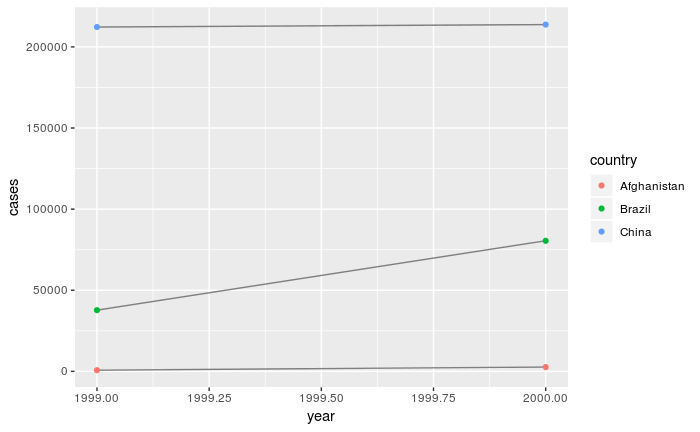

```r
# visualize changes over time
#library(ggplot2)
ggplot(table1, aes(year, cases)) +
  geom_line(aes(group = country), color = "grey50") +
  geom_point(aes(color = country))
```

### Spreading and Gathering

tidy data의 원리는 명확해서, tidy data가 아닌 것을 접해보지 않은 이상, 쉽게 상상하기 어렵다. 불행히도, 대부분의 실생활에서 마주치는 데이터들은 tidy 하지 않다. 그 이유는 크게 2가지 이다.

- 대부분의 사람들은 tidy data에 익숙하지 않다. 데이터를 다루는 데에 오랜 시간을 보내는 사람이 아닌 이상 tidy data가 가진 장점을 모르기 때문이다.
- 데이터를 제공하는 사람은 데이터를 분석하는 사람이 아닌 경우가 많다.

이러한 이유로 분석가는 실제 데이터를 분석하기 전에 먼저 tidy화 하는 과정을 필연적으로 거쳐야 함을 의미한다. tidy 를 하는 과정은 다음 2 단계를 먼저 고려해야 한다.

- 하나의 인자가 여러 열에 걸쳐 존재하는가
- 하나의 관측값이 여러 행에 걸쳐 존재하는가

이를 해결하기 위한 함수가 gather() 와 spread() 이다.

#### Gathering

일반적인 데이터셋이 가진 문제는, 하나의 열이 하나의 변수를 의미하지 않는데에 있다. table4a를 보면, 열의 이름이 1999, 2000 인데, 이는 년도(year) 를 반영하는 변수값이다. 또한 각 행은 하나가 아닌 두개의 관측값을 가지고 있다.

```r
table4a
```

|  | country | 1999 | 2000 |
| --- | --- | --- | --- |
| 1 | Afghanistan | 745 | 2666 |
| 2 | Brazil | 37737 | 80488 |
| 3 | China | 212258 | 213766 |

이를 해결하기 위해, 3개의 매개변수를 지정해야 한다. * 변수가 아닌 값을 의미하는 열의 집합. 이 예시에서는 1999, 2000 열에 해당한다. * 열의 이름을 구성할 변수의 이름. key 라고 정의했다. * 값이 여러 cell에 퍼져있는 변수의 이름. value 라고 정의했다.

```r
table4a %>%
  gather("1999","2000",key="year", value="cases")
```

| country | year | cases |
| --- | --- | --- |
| Afghanistan | 1999 | 745 |
| Brazil | 1999 | 37737 |
| China | 1999 | 212258 |
| Afghanistan | 2000 | 2666 |
| Brazil | 2000 | 80488 |
| China | 2000 | 213766 |

```r
table4b %>%
  gather("1999","2000", key="year", value="population")
```

| country | year | population |
| --- | --- | --- |
| Afghanistan | 1999 | 19987071 |
| Brazil | 1999 | 172006362 |
| China | 1999 | 1272915272 |
| Afghanistan | 2000 | 20595360 |
| Brazil | 2000 | 174504898 |
| China | 2000 | 1280428583 |

두개의 테이블을 하나의 테이블로 병합(join) 할 수 있다.

```r
tidy4a <- table4a %>%
  gather("1999","2000", key="year", value="cases")
tidy4b <- table4b %>%
  gather("1999","2000", key="year", value="population")
left_join(tidy4a, tidy4b)
```

| country | year | cases | population |
| --- | --- | --- | --- |
| Afghanistan | 1999 | 745 | 19987071 |
| Brazil | 1999 | 37737 | 172006362 |
| China | 1999 | 212258 | 1272915272 |
| Afghanistan | 2000 | 2666 | 20595360 |
| Brazil | 2000 | 80488 | 174504898 |
| China | 2000 | 213766 | 1280428583 |

### Spreading

- 변수 이름을 가지고 있는 열의 이름, key가 되는 열. 여기서는 type 이다
- 변수의 형태로 값을 가지고 있는 열의 이름. value가 되는 열. 여기서는 count이다.

```r
table2 %>% spread(key = type, value = count)
```

| country | year | cases | population |
| --- | --- | --- | --- |
| Afghanistan | 1999 | 745 | 19987071 |
| Afghanistan | 2000 | 2666 | 20595360 |
| Brazil | 1999 | 37737 | 172006362 |
| Brazil | 2000 | 80488 | 174504898 |
| China | 1999 | 212258 | 1272915272 |
| China | 2000 | 213766 | 1280428583 |

spread 와 gather 는 상호 반대되는 관계이다. gather()는 데이터를 좁고 길게 변환하고, spread는 데이터를 넓고 짧게 변환한다.

### Separating and Pull

하나의 열에 2개의 변수가 들어 있을 때, (case, population) seperate() 함수를 사용한다. 반대로 하나의 변수가 여러개의 열에 포함되어 있을 때, unite() 함수를 사용한다.

##### Separate

separate() 는 구분자를 기준으로 열을 나누는 함수이다. 기본 구분자는 / 이며, 구분자를 따로 지정할 수 도 있다.

```r
table3 %>%
  separate(
    rate, # rate 열을
    into=c("cases","population"), # cases 와 population 열로
    sep="/", # /를 구분자로 이용하여
    convert = TRUE # 적절한 데이터 타입으로 변환한다.
  )
```

|  | country | year | cases | population |
| --- | --- | --- | --- | --- |
| 1 | Afghanistan | 1999 | 745 | 19987071 |
| 2 | Afghanistan | 2000 | 2666 | 20595360 |
| 3 | Brazil | 1999 | 37737 | 172006362 |
| 4 | Brazil | 2000 | 80488 | 174504898 |
| 5 | China | 1999 | 212258 | 1272915272 |
| 6 | China | 2000 | 213766 | 1280428583 |

너비가 일정한 데이터를 나눌 때에는, sep 인자의 값에 정수 값을 넣어 나눈다.

```r
table3 %>%
  separate(
    year, # year 인자를
    into = c("century","decade", "year"), # 3개로 나누는데
    sep = c(2,3) # 2번째, 3번째에서 끊어라
  )
```

|  | country | century | decade | year | rate |
| --- | --- | --- | --- | --- | --- |
| 1 | Afghanistan | 19 | 9 | 9 | 745/19987071 |
| 2 | Afghanistan | 20 | 0 | 0 | 2666/20595360 |
| 3 | Brazil | 19 | 9 | 9 | 37737/172006362 |
| 4 | Brazil | 20 | 0 | 0 | 80488/174504898 |
| 5 | China | 19 | 9 | 9 | 212258/1272915272 |
| 6 | China | 20 | 0 | 0 | 213766/1280428583 |

##### Unite

separate() 의 반대이다. 여러개의 열을 하나의 열로 통합한다.

```r
table5 %>%
  unite(
    new, # new 라는 인자를
    century, year, # century와 year 인자를 붙여 생성한다.
    sep="" # 구분자는 공백으로 한다
  ) %>%
  separate(
    rate,
    into = c("cases", "populations"),
    convert = T

  )
```

| country | new | cases | populations |
| --- | --- | --- | --- |
| Afghanistan | 1999 | 745 | 19987071 |
| Afghanistan | 2000 | 2666 | 20595360 |
| Brazil | 1999 | 37737 | 172006362 |
| Brazil | 2000 | 80488 | 174504898 |
| China | 1999 | 212258 | 1272915272 |
| China | 2000 | 213766 | 1280428583 |

### Missing Values

데이터에는 항상 결측값이 있다는 것을 염두해 두어야 한다. 결측값의 종류는 두가지가 존재한다.

- explicitly. 결측값이라고 지정한 경우 (NA 로 표기)
- implicitly. 결측값이라고 지정하지 않은 경우 (단순히 그 cell에 값이 존재하지 않음)

2015년의 return 열의 값은 NA로 표기하여 결측값이라고 지정 되어있다. 반면 2016년의 경우 데이터셋에 존재하지 않는다.

```r
stocks <- tibble(
  year  =c(2015,2015,2015,2015,2016,2016,2016),
  qtr   =c(   1,   2,   3,   4,   2,   3,   4),
  return=c(1.88,0.59,0.35,  NA,0.92,0.17,2.66)
)
```

분기(qtr)별로 tidying 해보면, 빈 항목을 확인 할 수 있다.

```r
stocks %>% spread(year, return)
```

| qtr | 2015 | 2016 |
| --- | --- | --- |
| 1 | 1.88 | NA |
| 2 | 0.59 | 0.92 |
| 3 | 0.35 | 0.17 |
| 4 | NA | 2.66 |

na.rm 옵션을 이용하면, implicit/explicit NA 값을 제거할 수 있다.

```r
stocks %>%
  spread(year,return) %>%
  gather(year,return,"2015":"2016", na.rm = TRUE)
```

|  | qtr | year | return |
| --- | --- | --- | --- |
| 1 | 1 | 2015 | 1.88 |
| 2 | 2 | 2015 | 0.59 |
| 3 | 3 | 2015 | 0.35 |
| 4 | 2 | 2016 | 0.92 |
| 5 | 3 | 2016 | 0.17 |
| 6 | 4 | 2016 | 2.66 |

complete() 함수는 모든 유일한 조합을 산출하여 열을 구성한다. 조합상 정렬되어 위치되어야 할 곳에 맞춰 관측값을 삽입해 넣어준다.

```r
stocks %>%
  complete(year, qtr)
```

| year | qtr | return |
| --- | --- | --- |
| 2015 | 1 | 1.88 |
| 2015 | 2 | 0.59 |
| 2015 | 3 | 0.35 |
| 2015 | 4 | NA |
| 2016 | 1 | NA |
| 2016 | 2 | 0.92 |
| 2016 | 3 | 0.17 |
| 2016 | 4 | 2.66 |

fill() 함수는 가장 최근에 나왔었던 결측치가 아닌 값을 NA 위치에 채워 넣어준다.

```r
treatment <- tribble(
  ~ person, ~ treatment, ~response,
  "Derrick Whitmore", 1, 7,
  NA,                 2, 10,
  NA,                 3, 9,
  "Katherine Burke",  1, 4
)
treatment
```

| person | treatment | response |
| --- | --- | --- |
| Derrick Whitmore | 1 | 7 |
| NA | 2 | 10 |
| NA | 3 | 9 |
| Katherine Burke | 1 | 4 |

```r
treatment %>%
  fill(person)
```

| person | treatment | response |
| --- | --- | --- |
| Derrick Whitmore | 1 | 7 |
| Derrick Whitmore | 2 | 10 |
| Derrick Whitmore | 3 | 9 |
| Katherine Burke | 1 | 4 |